[figure not shown]

# Session 1: python syntax, variables, functions, list and loops

Welcome to the *IPython Notebook*. Through this interface, you'll be learning a lot of things:

- How to use iPython
- Some simple commands and syntax for exploring vocab with programming, specifically, the python library nltk
- How to use lists and indexing with Python to explore vocab
- Defining variables and functions in python
- Learning about loops and automating commands
- Turning words into data: tokenizing with nltk
- How to use nltk to remove common words and aid meaningful textual analysis
- Web scraping with nltk and beautiful soup

You can head [here](https://github.com/resbaz/lessons/blob/master/nltk/README.md) for the fully articulated overview of the course, but we'll almost always stay within IPython. Remember, everything we cover here will remain available to you after ResBaz is over, including these Notebooks. It's all accessible at the [ResBaz GitHub](https://github.com/resbaz/lessons/tree/master/nltk).

**Where am I!?**

Fair question. While your arrival might have been disorientating, you are on the cloud, using a virtual machine. Your virtual machine has its own command line or terminal, if you're using a Mac or Linux operating systems. In the old days, it was the only user interface available on a Unix computer. Nowadays, we have graphical user interfaces (GUIs) in addition to command line interfaces. But there are things you can do from the command line that you can't do with a GUI, such as clone a repository, like you just did.

This virutal machine has been setup to run an application. That application is the Jupyter Notebook, which is a spin-off of IPython, a tool for interactive computing on the web. Python is typically written as a standalone program on your computer. We run it off the cloud because of the amount of data we're using and also because it's cool.

If you'd like to install Python yourself, the best way to do it is to download [Anaconda](https://www.continuum.io/downloads). It's free.

The method for installing nltk is slightly different from what we are about to do on the cloud. Once you've installed the suite of tools that come with Anaconda (which includes the Jupyter Notebook), install NLTK from [here](http://www.nltk.org/install.html). Next, open the Jupyter Notebook on your machine and type "import nltk" into a cell (without the quotations).

Please note that if you are using very large datasets it will be slow. You can get your own cloud environment as a research for free. Research Platforms can assist you with that process if you need it.

**Any questions before we begin?**

Lets take a tour of the Jupyter Notebook.

So, now that you've had a play with the Jupyter notebook, some words on its utility.

## Text as data

Programming languages like Python are great for processing data. In order to apply it to *text*, we need to think about our text as data. This means being aware of how text is structured, what extra information might be encoded in it, and how to manage to give the best results.

## What is the Natural Language Toolkit?

We'll be covering some of the theory behind corpus linguistics later on, but let's start by looking at some of the tasks NLTK can help you with.

NLTK is a Python Library for working with written language data. It is free and extensively documented. Many areas we'll be covering are treated in more detail in the NLTK Book, available free online from [here](http://www.nltk.org/book/).

> Note: NLTK provides tools for tasks ranging from very simple (counting words in a text) to very complex (writing and training parsers, etc.). Many advanced tasks are beyond the scope of this course, but by the time we're done, you should understand Python and NLTK well enough to perform these tasks on your own!

We will start by importing NLTK, setting a path to NLTK resources, and downloading some additional stuff.

```python
from __future__ import print_function, division
# clear output from download
from IPython.display import display, clear_output
# import: all the nltk basics
import nltk
```

Oh, we've got to import some corpora used in the book as well...

```python
from nltk.book import *
# asterisk means 'everything'
```

```
*** Introductory Examples for the NLTK Book ***
Loading text1, ..., text9 and sent1, ..., sent9
Type the name of the text or sentence to view it.
Type: 'texts()' or 'sents()' to list the materials.
text1: Moby Dick by Herman Melville 1851
text2: Sense and Sensibility by Jane Austen 1811
text3: The Book of Genesis
text4: Inaugural Address Corpus
text5: Chat Corpus
text6: Monty Python and the Holy Grail
text7: Wall Street Journal
text8: Personals Corpus
text9: The Man Who Was Thursday by G . K . Chesterton 1908
```

```python
text2
#text3
```

```
<Text: Sense and Sensibility by Jane Austen 1811>
```

### Variables: why we use them

By assigning a variable you can save data to particular values. For example, Moby Dick is stored as Text1

Varibales are handy short cuts to our data and can be used in functions to determine the length of the data and so much more

Try assigning your own variable using this syntax: my_variable_name = 'the quality of mercy is not strained...'

```python
my_variable_name = 'the quality of mercy is not strained...'
```

Now "call" it. You can call a variable at anytime if you forget what data you saved to it, like we did above. Try using Tab complete.

```python
my_variable_name
```

```
'the quality of mercy is not strained...'
```

### Python syntax

The syntax of the Python programming language is the set of rules that defines how a Python program will be written and interpreted (by both computers and by human readers).

Python was designed to be a highly readable language. It has a relatively uncluttered visual layout and uses English keywords frequently where other languages use punctuation. So it's really the perfect computer language for our purposes.

The syntax we'll use the most are two types of commands; one that look like this len() and anothers that look like this .count()

Both need an object (text data in our case) to work on; for example, len(text1) or text1.count("Whale").

We are now going to play around with the first type of command.

### Exploring vocabulary

NLTK makes it really easy to get basic information about the size of a text and the complexity of its vocabulary.

**len(text1)** gives the number of symbols or 'tokens' in your text. This is the total number of words and items of punctuation.

**set(text2)** gives you a list of all the tokens in the text, without the duplicates.

Hence, **len(set(text3))** will give you the total number unique tokens. Remember this still includes punctuation.

**sorted(text4)** places items in the list into alphabetical order, with punctuation symbols and capitalised words first.

*Please* note that all these commands use the same *syntax*; this is the first python syntax we'll learn.

```python
len(text3)
```

```
44764
```

```python
len(set(text3))
```

```
2789
```

```python
sorted(set(text3)) [25:35]
```

```
[u'Achbor',
 u'Adah',
 u'Adam',
 u'Adbeel',
 u'Admah',
 u'Adullamite',
 u'After',
 u'Aholibamah',
 u'Ahuzzath',
 u'Ajah']
```

### Using iPython as a calculator

We can use the iPython environment as an overblown caluculator; try doing some basic mathematics with python. *Hint*: use * and / like your smartphone.

```python
3 * 4
```

```
12
```

The expression that you just wrote above is the most basic programming instruction in the Python language. It includes values (the numbers) and operators (* + - etc...) and always evaluate/reduce down to one value.

Operators are important and we can do more with them than multiply. We can ask IPython if something is equal to == or not equal to != and a number of others. Try it!

```python
3 == 4
```

```
False
```

```python
3 != 4
```

```
True
```

Handy! This introduces us to boolean operators. IPython is telling me whether the expressions I've type are True or False. More on operators later.

**Challenge!**

We can investigate the *lexical richness* of a text. For example, by dividing the total number of words by the number of unique words, we can see the average number of times each word is used.

For this challenge you will have to combine your knowledge of the syntax we've learnt so far and iPython's mathematical abilities.

Have a go at calculating the lexical richness of text3.

```python
len(text3)/len(set(text3))
```

```
16
```

```python
text4.count("America")
```

```
192
```

**Challenge!**

How would you calculate the percentage of Text 4 that is taken up by the word "America"?

```python
100*(text4.count("America")/len(text4))
```

```
0.13174597728754248
```

### Exploring text - concordances, similar contexts, dispersion

'Concordance' shows you a word in context and is useful if you want to be able to discuss the ways in which a word is used in a text. 'Similar' will find words used in similar contexts; remember it is not looking for synonyms, although the results may include synonyms

```python
text1.concordance("monstrous")
```

```
Displaying 11 of 11 matches:
ong the former , one was of a most monstrous size . ... This came towards us ,
ON OF THE PSALMS . " Touching that monstrous bulk of the whale or ork we have r
ll over with a heathenish array of monstrous clubs and spears . Some were thick
d as you gazed , and wondered what monstrous cannibal and savage could ever hav
that has survived the flood ; most monstrous and most mountainous ! That Himmal
they might scout at Moby Dick as a monstrous fable , or still worse and more de
th of Radney .'" CHAPTER 55 Of the Monstrous Pictures of Whales . I shall ere l
ing Scenes . In connexion with the monstrous pictures of whales , I am strongly
ere to enter upon those still more monstrous stories of them which are to be fo
ght have been rummaged out of this monstrous cabinet there is no telling . But
of Whale - Bones ; for Whales of a monstrous size are oftentimes cast up dead u
```

```python
text1.similar("monstrous")
```

```
imperial subtly impalpable pitiable curious abundant perilous
trustworthy untoward singular lamentable few determined maddens
horrible tyrannical lazy mystifying christian exasperate
```

```python
text2.similar("monstrous")
```

```
very exceedingly so heartily a great good amazingly as sweet
remarkably extremely vast
```

```python
text2.common_contexts(["monstrous", "very"])  # this function takes two arguments
```

```
a_pretty is_pretty a_lucky am_glad be_glad
```

We can also find words that typically occur together, which tend to be very specific to a text or genre of texts. We'll talk more about these features and how to use them later.

```python
text4.collocations()
```

```
United States; fellow citizens; four years; years ago; Federal
Government; General Government; American people; Vice President; Old
World; Almighty God; Fellow citizens; Chief Magistrate; Chief Justice;
God bless; every citizen; Indian tribes; public debt; one another;
foreign nations; political parties
```

```python
text3.collocations()
```

```
said unto; pray thee; thou shalt; thou hast; thy seed; years old;
spake unto; thou art; LORD God; every living; God hath; begat sons;
seven years; shalt thou; little ones; living creature; creeping thing;
savoury meat; thirty years; every beast
```

**Challenge!**

1. Find the collocations in Gensis.
2. Chose one of the creepier words to concordance.
3. Investigate how the word is used. What words are used similarly?
4. And what are the common contexts of these words?
5. Report your findings to the person next to you.
6. Do the same with the chat forum.

Python also lets you create graphs to display data. To represent information about a text graphically, import the Python library *numpy*. We can then generate a dispersion plot that shows where given words occur in a text.

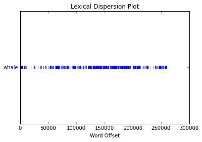

```python
import numpy
%matplotlib inline
text1.dispersion_plot(["whale"])
```

```python
text1.count('whale')
```

```
906
```

**Challenge!**  
Create a dispersion plot for the terms "citizens", "democracy", "freedom", "duties" and "America" in the innaugural address corpus. What do you think it tells you?

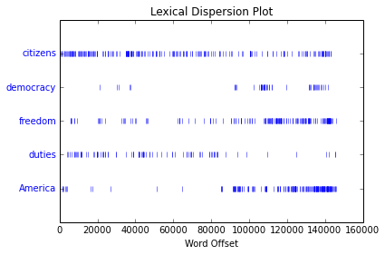

```python
text4.dispersion_plot(["citizens", "democracy", "freedom", "duties", "America"]) # plot five words longitudinally
```

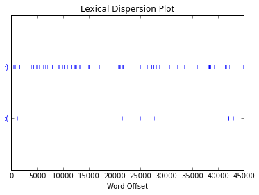

```python
text5.dispersion_plot([":)", ":("])
```

### Writing our own functions (yay!)

One thing that makes Python unique is that whitespace at the start of the line (use four spaces for consistency!) is meaningful. In many other languages, whitespace at the start of lines is simply a readability convention.

```python
# Fix this whitespace problem!

string = 'user'
if string == 'user':
print('Phew, fixed.')
```

```
  File "<ipython-input-20-252919a0783a>", line 5
    print('Phew, fixed.')
        ^
IndentationError: expected an indented block
```

So, whitespace tells both Python and human readers where things start and stop.